← Volver al inicio

# Distribuciones teóricas y correlaciones — repaso con teoría

Este notebook intercala el código real de `Distribuciones y correlaciones.R` (material de clase, autor: Andres Salas) con la explicación conceptual: qué distribución se usa, por qué, y cómo se llega de “graficar una densidad teórica” a “construir la matriz de correlaciones entre varias acciones” — que es exactamente el insumo que se necesita más adelante para optimización de portafolios (varianza de un portafolio = combinación de varianzas individuales **y** covarianzas entre activos).

## Configuración inicial

▸ código

```r
if (!require("pacman")) install.packages("pacman")
```

▸ código

```r
pacman::p_load(tidyverse, EnvStats, ggpubr, quantmod, TTR, ggcorrplot, xts)
options(scipen = 999)
```

# Parte 1 — Distribución discreta de probabilidad

**Qué hace**: define a mano una distribución de probabilidad discreta (unos pocos precios posibles, cada uno con su propia probabilidad) y la grafica de dos formas: función de masa (`pmf`, la probabilidad de cada valor exacto) y función de probabilidad acumulada (`cdf`, $P(X \le x)$).

**Por qué (teoría)**: es discreta porque el precio solo puede tomar esos 6 valores puntuales (450, 460, …, 500) — no cualquier número entre medio. Por eso el gráfico correcto es de **barras/columnas**, no una curva continua: no tiene sentido “interpolar” entre 460 y 470 porque esos valores intermedios tienen probabilidad cero por definición del problema. La `cdf` siempre es una función escalonada (step function) en una distribución discreta, porque salta de golpe en cada uno de los valores posibles.

▸ código

```r
precios <- data.frame(precio = seq(from = 450, to = 500, by = 10),
                      prob = c(0.1, 0.15, 0.25, 0.3, 0.1, 0.1))
precios
```

| precio | prob |
| --- | --- |
| 450 | 0.10 |
| 460 | 0.15 |
| 470 | 0.25 |
| 480 | 0.30 |
| 490 | 0.10 |
| 500 | 0.10 |

▸ código

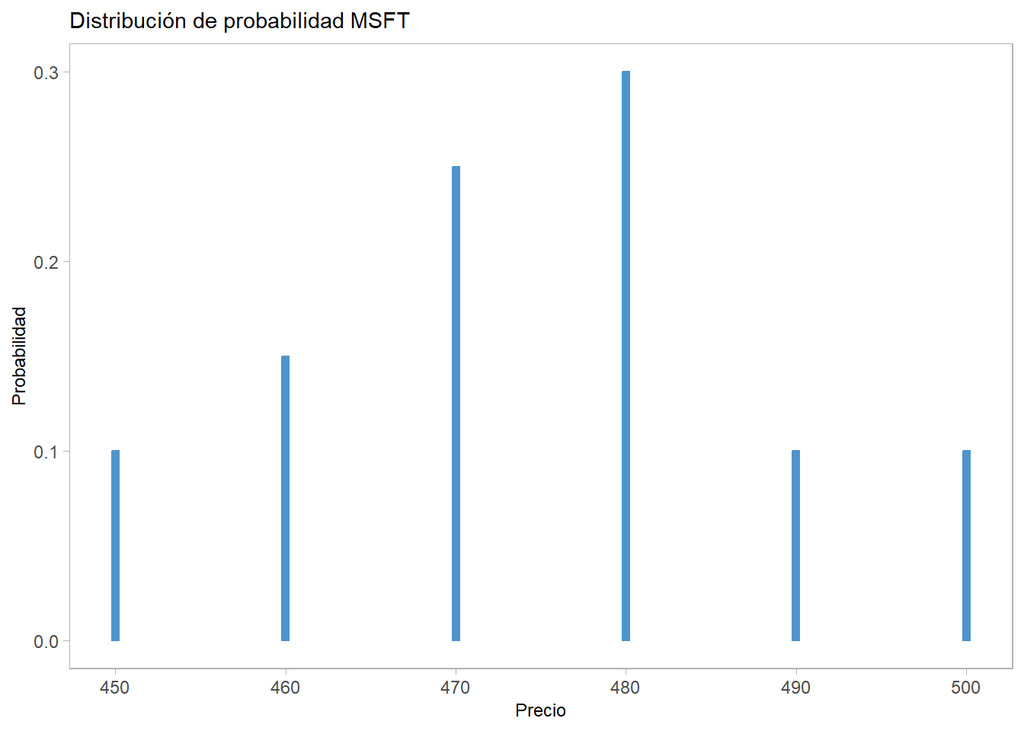

```r
grafico_masa <- ggplot2::ggplot(data = precios, mapping = aes(x = precio, y = prob)) +
  ggplot2::geom_col(color = "steelblue3", fill = "steelblue3", width = 0.4) +
  theme_light() +
  ggplot2::labs(x = "Precio", y = "Probabilidad", title = "Distribución de probabilidad MSFT") +
  theme(axis.title = element_text(size = 9),
        axis.text = element_text(size = 9),
        plot.title = element_text(size = 11),
        panel.grid = element_blank())
grafico_masa
```

▸ código

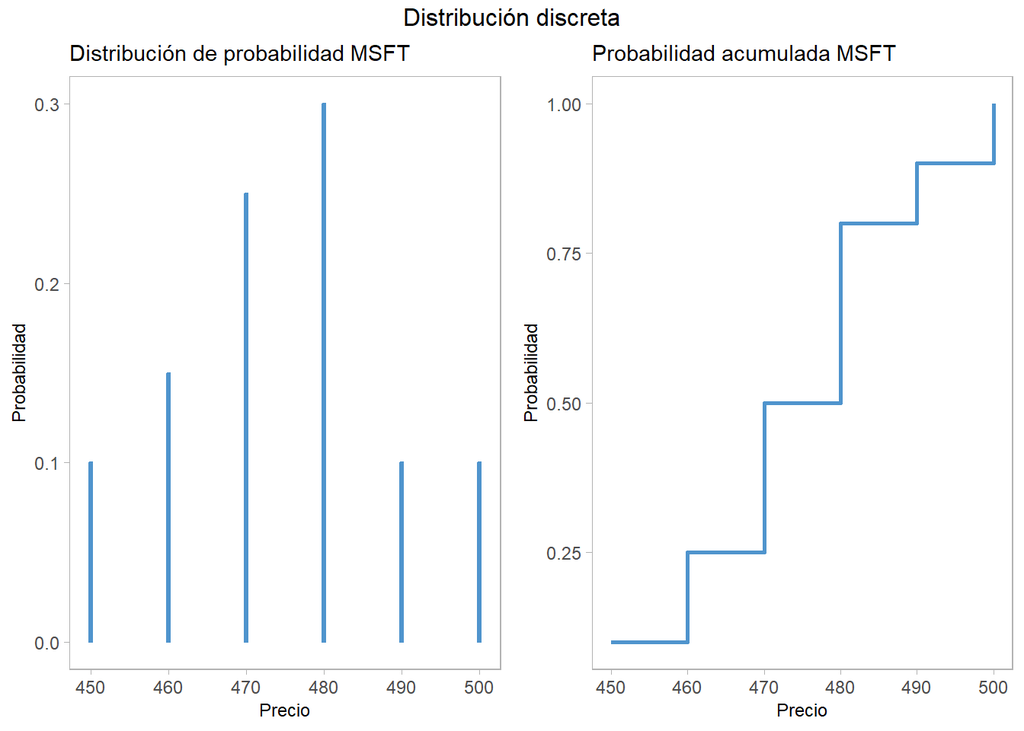

```r
grafico_prob <- ggplot2::ggplot(data = precios, mapping = aes(x = precio, y = cumsum(prob))) +
  ggplot2::geom_step(color = "steelblue3", lwd = 1) +
  theme_light() +
  ggplot2::labs(x = "Precio", y = "Probabilidad", title = "Probabilidad acumulada MSFT") +
  theme(axis.title = element_text(size = 9),
        axis.text = element_text(size = 9),
        plot.title = element_text(size = 11),
        panel.grid = element_blank())

ggpubr::ggarrange(ncol = 2, plotlist = list(grafico_masa, grafico_prob)) %>%
  ggpubr::annotate_figure(top = "Distribución discreta")
```

# Parte 2 — Distribución triangular

**Qué hace**: grafica la densidad y la acumulada de una **Triangular** con mínimo, moda (valor más probable) y máximo definidos a mano.

▸ código

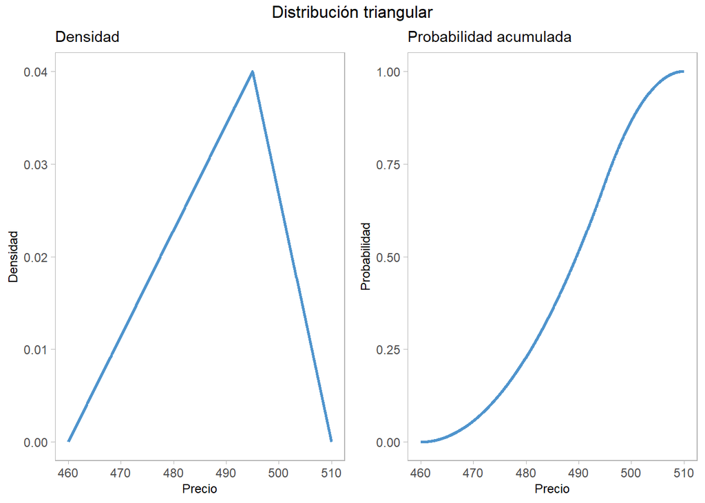

```r
minimo <- 460
moda <- 495
maximo <- 510

densidad_tri <- ggplot(data = data.frame(x = c(minimo, maximo)), mapping = aes(x)) +
  stat_function(fun = EnvStats::dtri,
                n=1001,
                args = list(min = minimo, max = maximo, mode = moda),
                color = "steelblue3",
                lwd = 1) +
  theme_light() +
  labs(y = "Densidad", x = "Precio", title = "Densidad") +
  theme(axis.title = element_text(size = 9),
        axis.text = element_text(size = 9),
        plot.title = element_text(size = 11),
        panel.grid = element_blank())

probabilidad_tri <- ggplot(data = data.frame(x = c(minimo, maximo)), mapping = aes(x)) +
  stat_function(fun = EnvStats::ptri,
                n=1001,
                args = list(min = minimo, max = maximo, mode = moda),
                color = "steelblue3",
                lwd = 1) +
  theme_light() +
  labs(y = "Probabilidad", x = "Precio", title = "Probabilidad acumulada") +
  theme(axis.title = element_text(size = 9),
        axis.text = element_text(size = 9),
        plot.title = element_text(size = 11),
        panel.grid = element_blank())

ggpubr::ggarrange(ncol = 2, plotlist = list(densidad_tri, probabilidad_tri)) %>%
  ggpubr::annotate_figure(top = "Distribución triangular")
```

# Parte 3 — Distribución normal

**Qué hace**: grafica densidad y acumulada de una Normal con media y desviación estándar dadas.

**Por qué (teoría)**: la Normal aparece cuando el resultado es la **suma** de muchos efectos pequeños e independientes (Teorema Central del Límite) — por eso es la distribución por defecto para variables como retornos de una acción (acumulación de muchas noticias/decisiones diarias). A diferencia de la Triangular, **no está acotada**: en teoría permite cualquier valor, aunque con probabilidad cada vez más chica mientras más lejos de la media (por eso aquí se grafica solo `media ± 4·desviación`, donde ya casi toda el área bajo la curva está contenida).

▸ código

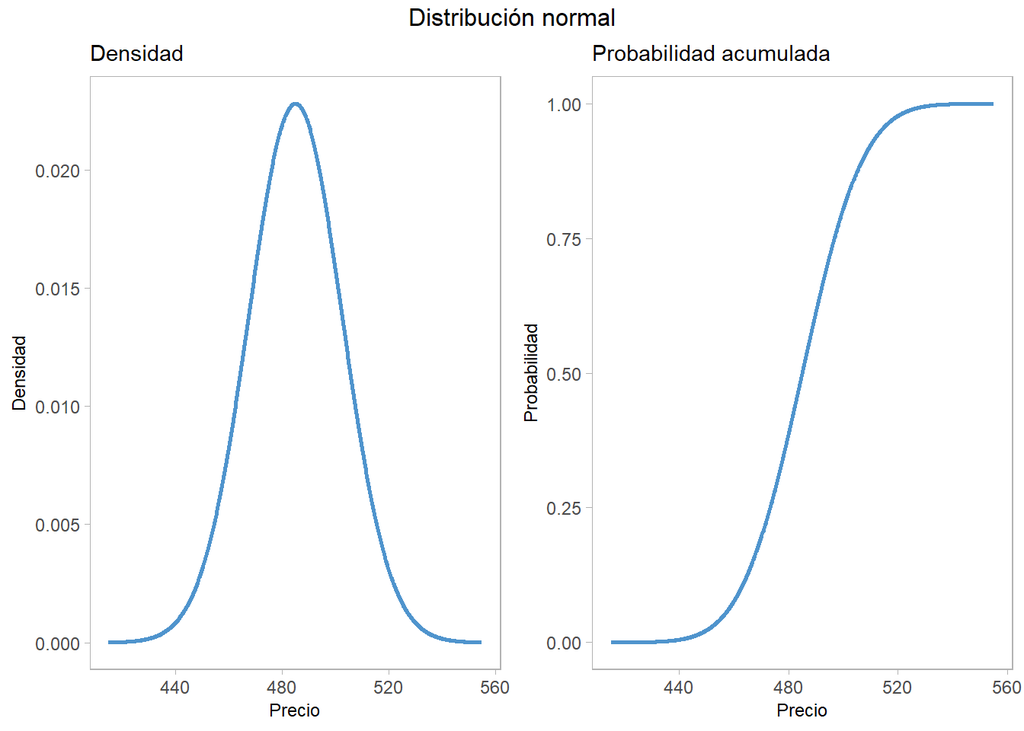

```r
media <- 485
desv.estandar <- 17.5
rango_min <- media - 4*desv.estandar
rango_max <- media + 4*desv.estandar

densidad_norm <- ggplot(data = data.frame(x = c(rango_min, rango_max)), mapping = aes(x)) +
  stat_function(fun = dnorm,
                n=1001,
                args = list(mean = media, sd = desv.estandar),
                color = "steelblue3",
                lwd = 1) +
  theme_light() +
  labs(y = "Densidad", x = "Precio", title = "Densidad") +
  theme(axis.title = element_text(size = 9),
        axis.text = element_text(size = 9),
        plot.title = element_text(size = 11),
        panel.grid = element_blank())

probabilidad_norm <- ggplot(data = data.frame(x = c(rango_min, rango_max)), mapping = aes(x)) +
  stat_function(fun = pnorm,
                n=1001,
                args = list(mean = media, sd = desv.estandar),
                color = "steelblue3",
                lwd = 1) +
  theme_light() +
  labs(y = "Probabilidad", x = "Precio", title = "Probabilidad acumulada") +
  theme(axis.title = element_text(size = 9),
        axis.text = element_text(size = 9),
        plot.title = element_text(size = 11),
        panel.grid = element_blank())

ggpubr::ggarrange(ncol = 2, plotlist = list(densidad_norm, probabilidad_norm)) %>%
  ggpubr::annotate_figure(top = "Distribución normal")
```

# Parte 4 — Percentiles teóricos: Normal vs. Triangular

**Qué hace**: en vez de simular, calcula percentiles **exactos** (la función cuantil, inversa de la acumulada) tanto para la Normal como para la Triangular de las dos secciones anteriores.

**Por qué (teoría)**: cuando se conoce la distribución de una variable de forma analítica, no hace falta simular para saber, por ejemplo, “¿bajo qué precio cae el 5% peor de los casos?” — se resuelve directo con la función cuantil ($Q(p)$, la inversa de la $cdf$). Esto es exactamente el mismo principio detrás del **VaR (Value at Risk)**: un percentil bajo (p.ej. 5%) de la distribución de pérdidas/retornos. Comparar los cuantiles de la Normal contra los de la Triangular en este mismo rango de precios permite ver en números concretos lo que ya se explicó en el taller: la Triangular, al estar acotada, nunca da un percentil tan extremo como la Normal en las colas.

▸ código

```r
cuartil <- c(0.25, 0.5, 0.75)
valor_cuartil <- qnorm(p = cuartil, mean = media, sd = desv.estandar)
cuartil_normal <- data.frame(cuartil, valor_cuartil)
cuartil_normal
```

| cuartil | valor_cuartil |
| --- | --- |
| 0.25 | 473.1964 |
| 0.50 | 485.0000 |
| 0.75 | 496.8036 |

▸ código

```r
percentil <- seq(from = 0.05, to = 0.95, by = 0.05)
valor_percentil <- qnorm(p = percentil, mean = media, sd = desv.estandar)
percentil_normal <- data.frame(percentil, valor_percentil)
percentil_normal
```

| percentil | valor_percentil |
| --- | --- |
| 0.05 | 456.2151 |
| 0.10 | 462.5728 |
| 0.15 | 466.8624 |
| 0.20 | 470.2716 |
| 0.25 | 473.1964 |
| 0.30 | 475.8230 |
| 0.35 | 478.2569 |
| 0.40 | 480.5664 |
| 0.45 | 482.8009 |
| 0.50 | 485.0000 |

[output cut: 9 more lines]

▸ código

```r
tri_cuartil <- EnvStats::qtri(p = cuartil, min = minimo, max = maximo, mode = moda)
cuartil_tri <- data.frame(cuartil, tri_cuartil)
cuartil_tri
```

| cuartil | tri_cuartil |
| --- | --- |
| 0.25 | 480.9165 |
| 0.50 | 489.5804 |
| 0.75 | 496.3069 |

▸ código

```r
tri_percentil <- EnvStats::qtri(p = percentil, min = minimo, max = maximo, mode = moda)
percentil_tri <- data.frame(percentil, tri_percentil)
percentil_tri
```

| percentil | tri_percentil |
| --- | --- |
| 0.05 | 469.3541 |
| 0.10 | 473.2288 |
| 0.15 | 476.2019 |
| 0.20 | 478.7083 |
| 0.25 | 480.9165 |
| 0.30 | 482.9129 |
| 0.35 | 484.7487 |
| 0.40 | 486.4575 |
| 0.45 | 488.0624 |
| 0.50 | 489.5804 |

[output cut: 9 more lines]

**Comparación (percentil 5%, el más relevante para riesgo de cola)**: la Normal da un valor de 456.2, mientras que la Triangular da 469.4 — la Triangular queda **acotada por su propio mínimo** (460), así que su percentil 5% nunca puede bajar de ese piso, sin importar qué tan extremo sea el percentil que se pida. La Normal, en cambio, no tiene ese piso: sigue bajando (aunque cada vez con menos probabilidad) mientras más extremo el percentil.

# Parte 5 — Datos reales: precios y retornos de varias acciones

**Qué hace**: descarga precios diarios ajustados de 15 acciones reales desde Yahoo Finance, los convierte a precios de cierre mensual, y calcula el retorno logarítmico mensual de cada una.

**Por qué (teoría)**: el **retorno logarítmico** ($\ln(P_t/P_{t-1})$) se usa en vez del retorno simple ($P_t/P_{t-1} - 1$) porque es **aditivo en el tiempo** (el retorno de 2 meses es la suma de los retornos logarítmicos de cada mes, no su producto) y porque es la cantidad que de verdad se comporta aproximadamente Normal — el **precio**, en cambio, es lognormal (producto de retornos, siempre positivo), no normal.

▸ código

```r
acciones <- c("NVDA", "AAPL", "AMZN", "TSLA", "PG", "LLY", "NFLX", "ABT",
              "MSFT", "INTC", "BBVA", "CRSR", "DB", "DUOL", "HOG")

precio_diario <- quantmod::getSymbols(acciones, src = "yahoo",
                               from = "2018-12-31",
                               periodicity = "daily",
                               auto.assign = TRUE,
                               warnings = FALSE) %>%
  purrr::map(~quantmod::Ad(get(.))) %>% # Extrae solo el precio ajustado de cada accion
  purrr::reduce(merge.xts) %>% # Fusiona los items de la lista usando las fechas como indices
  `colnames<-`(acciones) # Cambia los nombres de columna a los simbolos

precio <- xts::to.monthly(x = precio_diario,
                          indexAt = "lastof",
                          OHLC = FALSE)
```

▸ código

```r
head(precio)
```

```
##                NVDA     AAPL     AMZN     TSLA       PG      LLY   NFLX
## 2021-07-31 19.43179 142.1773 166.3795 229.0667 125.0848 232.2785 51.757
## 2021-08-31 22.31177 148.2183 173.5395 245.2400 125.2255 247.1825 56.919
## 2021-09-30 20.64823 138.1341 164.2520 258.4933 122.9477 221.1140 61.034
## 2021-10-31 25.48336 146.2366 168.6215 371.3333 126.5328 243.8043 69.031
## 2021-11-30 32.56910 161.6034 175.3535 381.5867 127.9398 238.1441 64.190
## 2021-12-31 29.31838 173.5990 166.7170 352.2600 144.7530 265.1997 60.244
##                 ABT     MSFT     INTC     BBVA  CRSR       DB   DUOL      HOG
## 2021-07-31 109.7691 273.4272 49.15995 4.663812 29.19 10.82807 140.25 35.54554
## 2021-08-31 114.6596 290.2678 49.79256 4.788279 28.95 10.68958 129.56 35.46478
## 2021-09-30 107.1832 271.0757 49.07414 4.824886 25.93 10.99252 166.36 32.97843
## 2021-10-31 117.3976 318.8639 45.13198 5.172927 24.45 11.09639 173.69 32.87033
## 2021-11-30 114.5558 318.4551 45.63135 3.933504 22.40 10.40395 110.19 32.99644
## 2021-12-31 128.1910 323.9748 47.76452 4.356540 21.01 10.81941 106.11 34.08698
```

## Cálculo de los retornos — y un bug real de `TTR::ROC`

El script original de clase usa `TTR::ROC(x, type="continuous", na.pad=F)` para el retorno logarítmico. **Ese código tiene un bug real** (ya detectado al resolver el taller, aquí se confirma que es más grave de lo que parecía): con `na.pad=FALSE` sobre una serie ya convertida a mensual, `ROC` no solo calcula mal la primera fila — **desalinea toda la serie**, corriendo el índice de fechas contra los valores.

▸ código

```r
retornos_roc <- TTR::ROC(x = precio, type = "continuous", na.pad = F) %>%
  `colnames<-`(acciones)

retornos_correctos <- diff(log(precio)) %>% na.omit() %>% `colnames<-`(acciones)

# Comparación directa, primeras filas de AAPL
data.frame(
  fecha = index(retornos_roc)[1:5],
  ROC_bug = as.numeric(retornos_roc[1:5, "AAPL"]),
  manual_correcto = as.numeric(retornos_correctos[1:5, "AAPL"])
)
```

| fecha | ROC_bug | manual_correcto |
| --- | --- | --- |
| 2021-08-31 | -0.30337391 | 0.04161152 |
| 2021-09-30 | -0.02885023 | -0.07046175 |
| 2021-10-31 | -0.01346057 | 0.05700119 |
| 2021-11-30 | 0.15692064 | 0.09991946 |
| 2021-12-31 | 0.17152233 | 0.07160288 |

▸ código

```r
retornos <- retornos_correctos
head(retornos)
```

```
##                   NVDA        AAPL        AMZN        TSLA           PG
## 2021-08-31  0.13820415  0.04161152  0.04213394  0.06822427  0.001124215
## 2021-09-30 -0.07748473 -0.07046175 -0.05500344  0.05263261 -0.018356875
## 2021-10-31  0.21039588  0.05700119  0.02625477  0.36223020  0.028742119
## 2021-11-30  0.24533853  0.09991946  0.03914735  0.02723785  0.011058082
## 2021-12-31 -0.10514945  0.07160288 -0.05050620 -0.07996844  0.123469368
## 2022-01-31 -0.18326723 -0.01583690 -0.10850981 -0.12059748 -0.013935103
##                    LLY        NFLX         ABT         MSFT        INTC
## 2021-08-31  0.06218987  0.09506949  0.04358878  0.059768558  0.01278631
## 2021-09-30 -0.11144884  0.06980191 -0.06742840 -0.068405965 -0.01453332
## 2021-10-31  0.09768768  0.12312456  0.09102718  0.162366187 -0.08374108
## 2021-11-30 -0.02349010 -0.07270818 -0.02450460 -0.001282725  0.01100382
## 2021-12-31  0.10760743 -0.06344450  0.11245957  0.017184193  0.04568807
## 2022-01-31 -0.11834863 -0.34387622 -0.09559073 -0.078334587 -0.05344177
##                    BBVA         CRSR           DB        DUOL          HOG
## 2021-08-31  0.026337897 -0.008255973 -0.012872378 -0.07928247 -0.002274519
## 2021-09-30  0.007616107 -0.110169619  0.027945992  0.25001004 -0.072686521
## 2021-10-31  0.069651585 -0.058770364  0.009404478  0.04311800 -0.003283312
## 2021-11-30 -0.273908123 -0.087569305 -0.064434390 -0.45506594  0.003829368
## 2021-12-31  0.102147674 -0.064062416  0.039156616 -0.03772987  0.032515869
## 2022-01-31  0.083313413 -0.072534832  0.105440486 -0.05920610 -0.086408645
```

# Parte 6 — Matriz de varianzas y covarianzas

**Qué hace**: calcula la matriz de varianzas-covarianzas de los 15 retornos.

**Por qué (teoría)**: la covarianza entre dos activos mide si se mueven juntos (positiva) o en direcciones opuestas (negativa). Es el insumo central de la teoría de portafolios de Markowitz: la varianza de un portafolio **no es** el promedio ponderado de las varianzas individuales — depende también de cuánto covarían entre sí los activos. Dos activos con la misma varianza individual pueden dar un portafolio mucho más o menos riesgoso dependiendo de si su covarianza es alta o baja (o negativa).

▸ código

```r
varianzas <- var(retornos)
round(varianzas, 5)
```

```
##         NVDA    AAPL     AMZN     TSLA       PG      LLY    NFLX      ABT
## NVDA 0.01991 0.00531  0.00913  0.01028  0.00032  0.00165 0.01137  0.00106
## AAPL 0.00531 0.00495  0.00360  0.00586  0.00063  0.00148 0.00379  0.00110
## AMZN 0.00913 0.00360  0.00913  0.00802 -0.00053  0.00034 0.00692  0.00039
## TSLA 0.01028 0.00586  0.00802  0.02906 -0.00156 -0.00162 0.00721 -0.00052
## PG   0.00032 0.00063 -0.00053 -0.00156  0.00276  0.00104 0.00017  0.00158
## LLY  0.00165 0.00148  0.00034 -0.00162  0.00104  0.00805 0.00206  0.00168
## NFLX 0.01137 0.00379  0.00692  0.00721  0.00017  0.00206 0.01985  0.00314
## ABT  0.00106 0.00110  0.00039 -0.00052  0.00158  0.00168 0.00314  0.00430
## MSFT 0.00691 0.00287  0.00482  0.00350  0.00055  0.00097 0.00484  0.00164
## INTC 0.00680 0.00410  0.00491  0.00674  0.00164  0.00186 0.00184 -0.00106
## BBVA 0.00124 0.00054  0.00059 -0.00016  0.00088  0.00068 0.00137  0.00211
## CRSR 0.01029 0.00466  0.00646  0.00505  0.00049  0.00007 0.00771  0.00168
## DB   0.00355 0.00109  0.00182 -0.00004  0.00050  0.00025 0.00402  0.00215
## DUOL 0.00283 0.00026  0.00531  0.01111 -0.00059 -0.00150 0.00591  0.00161
## HOG  0.00437 0.00238  0.00271  0.00427  0.00050 -0.00172 0.00250  0.00116
##         MSFT     INTC     BBVA    CRSR       DB     DUOL      HOG
## NVDA 0.00691  0.00680  0.00124 0.01029  0.00355  0.00283  0.00437
## AAPL 0.00287  0.00410  0.00054 0.00466  0.00109  0.00026  0.00238
## AMZN 0.00482  0.00491  0.00059 0.00646  0.00182  0.00531  0.00271
## TSLA 0.00350  0.00674 -0.00016 0.00505 -0.00004  0.01111  0.00427
## PG   0.00055  0.00164  0.00088 0.00049  0.00050 -0.00059  0.00050
## LLY  0.00097  0.00186  0.00068 0.00007  0.00025 -0.00150 -0.00172
## NFLX 0.00484  0.00184  0.00137 0.00771  0.00402  0.00591  0.00250
## ABT  0.00164 -0.00106  0.00211 0.00168  0.00215  0.00161  0.00116
## MSFT 0.00593  0.00137  0.00114 0.00590  0.00157  0.00457  0.00136
## INTC 0.00137  0.03034  0.00252 0.01006  0.00233  0.00096  0.00685
## BBVA 0.00114  0.00252  0.00761 0.00298  0.00593  0.00138  0.00339
## CRSR 0.00590  0.01006  0.00298 0.02722  0.00482  0.00465  0.00632
## DB   0.00157  0.00233  0.00593 0.00482  0.00891  0.00135  0.00342
## DUOL 0.00457  0.00096  0.00138 0.00465  0.00135  0.03141  0.00016
## HOG  0.00136  0.00685  0.00339 0.00632  0.00342  0.00016  0.01281
```

# Parte 7 — Matriz de correlación

**Qué hace**: calcula y grafica la matriz de correlación (la covarianza normalizada, siempre entre -1 y 1) entre los 15 activos.

**Por qué (teoría)**: la correlación es la misma información que la covarianza pero en una escala interpretable directamente (-1 = inversamente proporcionales, 0 = sin relación lineal, 1 = se mueven exactamente igual). El beneficio de diversificar un portafolio depende de **qué tan baja** es esta correlación entre los activos que lo componen — combinar activos con correlación cercana a 1 casi no reduce el riesgo total, mientras que combinar activos con correlación baja o negativa sí lo hace.

▸ código

```r
correlaciones <- cor(retornos)
round(correlaciones, 2)
```

```
##      NVDA AAPL  AMZN  TSLA    PG   LLY NFLX   ABT MSFT  INTC  BBVA CRSR   DB
## NVDA 1.00 0.53  0.68  0.43  0.04  0.13 0.57  0.11 0.64  0.28  0.10 0.44 0.27
## AAPL 0.53 1.00  0.53  0.49  0.17  0.23 0.38  0.24 0.53  0.33  0.09 0.40 0.16
## AMZN 0.68 0.53  1.00  0.49 -0.11  0.04 0.51  0.06 0.65  0.29  0.07 0.41 0.20
## TSLA 0.43 0.49  0.49  1.00 -0.17 -0.11 0.30 -0.05 0.27  0.23 -0.01 0.18 0.00
## PG   0.04 0.17 -0.11 -0.17  1.00  0.22 0.02  0.46 0.14  0.18  0.19 0.06 0.10
## LLY  0.13 0.23  0.04 -0.11  0.22  1.00 0.16  0.29 0.14  0.12  0.09 0.00 0.03
## NFLX 0.57 0.38  0.51  0.30  0.02  0.16 1.00  0.34 0.45  0.07  0.11 0.33 0.30
## ABT  0.11 0.24  0.06 -0.05  0.46  0.29 0.34  1.00 0.33 -0.09  0.37 0.16 0.35
## MSFT 0.64 0.53  0.65  0.27  0.14  0.14 0.45  0.33 1.00  0.10  0.17 0.46 0.22
## INTC 0.28 0.33  0.29  0.23  0.18  0.12 0.07 -0.09 0.10  1.00  0.17 0.35 0.14
## BBVA 0.10 0.09  0.07 -0.01  0.19  0.09 0.11  0.37 0.17  0.17  1.00 0.21 0.72
## CRSR 0.44 0.40  0.41  0.18  0.06  0.00 0.33  0.16 0.46  0.35  0.21 1.00 0.31
## DB   0.27 0.16  0.20  0.00  0.10  0.03 0.30  0.35 0.22  0.14  0.72 0.31 1.00
## DUOL 0.11 0.02  0.31  0.37 -0.06 -0.09 0.24  0.14 0.34  0.03  0.09 0.16 0.08
## HOG  0.27 0.30  0.25  0.22  0.08 -0.17 0.16  0.16 0.16  0.35  0.34 0.34 0.32
##       DUOL   HOG
## NVDA  0.11  0.27
## AAPL  0.02  0.30
## AMZN  0.31  0.25
## TSLA  0.37  0.22
## PG   -0.06  0.08
## LLY  -0.09 -0.17
## NFLX  0.24  0.16
## ABT   0.14  0.16
## MSFT  0.34  0.16
## INTC  0.03  0.35
## BBVA  0.09  0.34
## CRSR  0.16  0.34
## DB    0.08  0.32
## DUOL  1.00  0.01
## HOG   0.01  1.00
```

▸ código

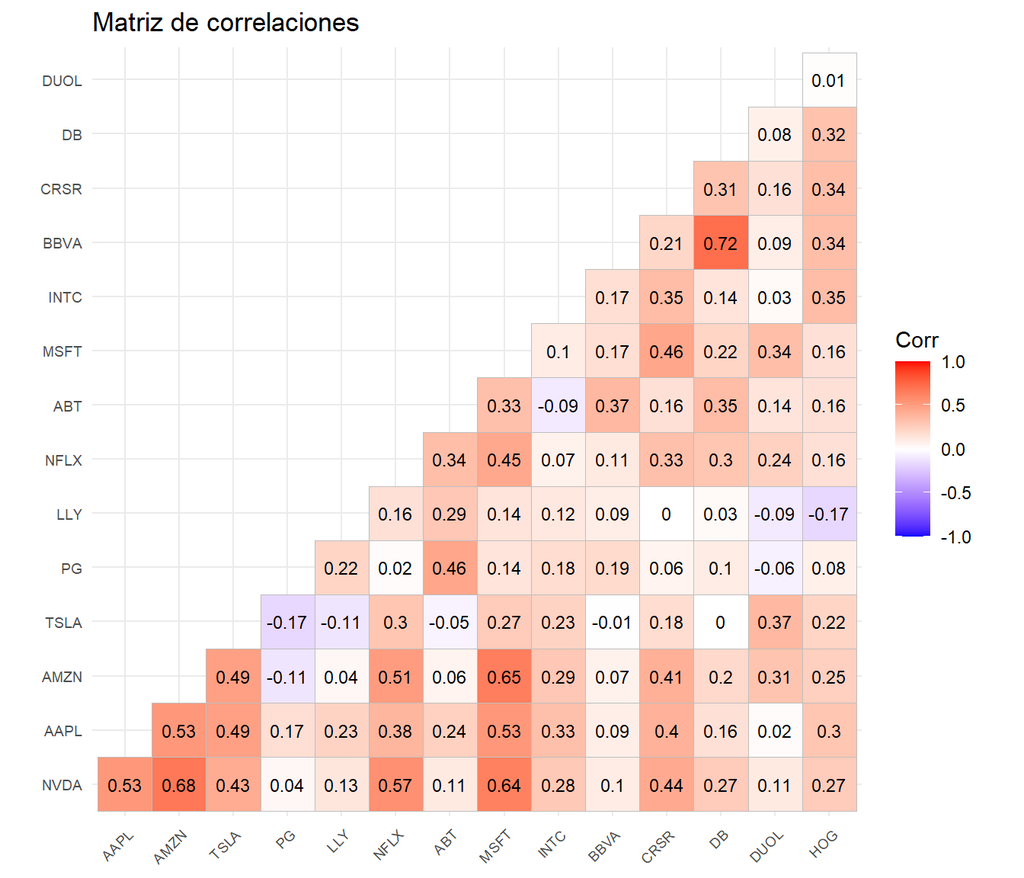

```r
ggcorrplot::ggcorrplot(correlaciones,
                       lab = T,
                       type = "lower",
                       lab_size = 3,
                       tl.cex = 7,
                       title = "Matriz de correlaciones")
```

# Parte 8 — Significancia estadística de las correlaciones

**Por qué (teoría)**: con pocas observaciones (acá solo 61 meses), una correlación muestral puede verse distinta de 0 solo por ruido de muestreo, sin que exista una relación real entre esos dos activos. El test de significancia (basado en el estadístico $t = r\sqrt{\frac{n-2}{1-r^2}}$) filtra esas correlaciones poco confiables — importante antes de usar la matriz completa como insumo de una optimización de portafolio: incluir una covarianza que en realidad es ruido puede llevar a una asignación de pesos que no tiene ningún fundamento real.

▸ código

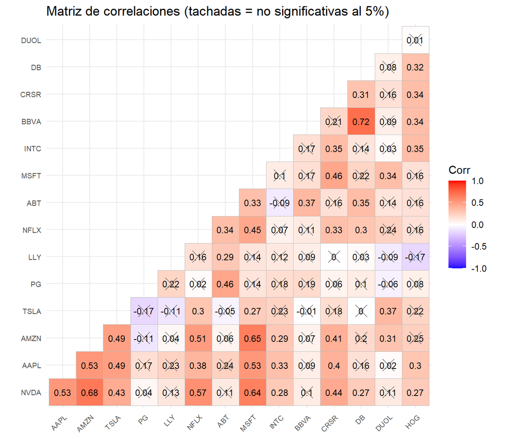

```r
p_mat <- ggcorrplot::cor_pmat(retornos)

ggcorrplot::ggcorrplot(correlaciones,
                       lab = T,
                       type = "lower",
                       lab_size = 3,
                       tl.cex = 7,
                       title = "Matriz de correlaciones (tachadas = no significativas al 5%)",
                       p.mat = p_mat,
                       sig.level = 0.05)
```